# 簡歷

Jing Dian Hsu

# 許靖典

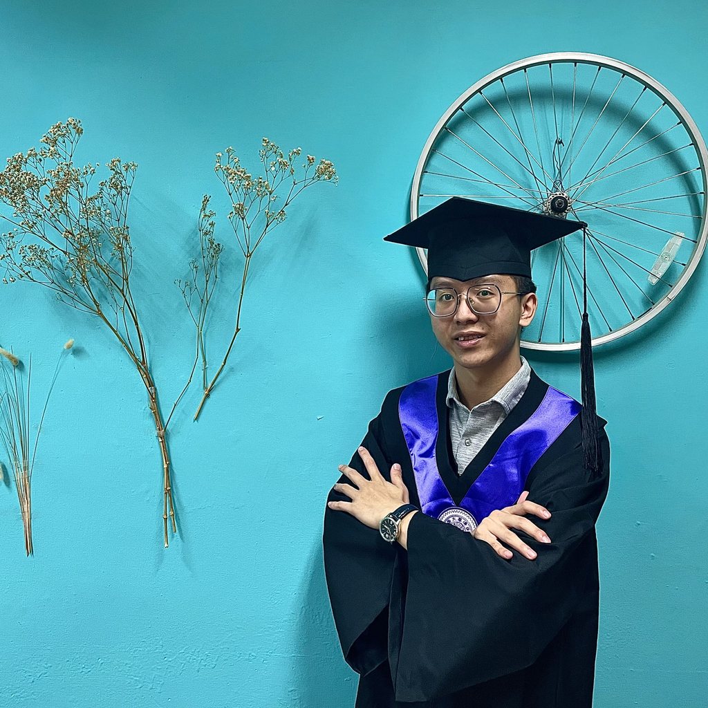

[figure not shown]

Github: https://github.com/howardhsu123 Email： howardhsu123@gmail.com

## 介绍

對於學習有熱忱，且願意多元嘗試。目標是希望成為一個兼具開發能力的分析師。

## 經歷

### 2018

- 創立清華區塊鏈研究社

> 清交第一個區塊鏈相關項目。

### 2019

- 參與仁齋自治團隊

> 實作簡易的Python空間借用系統

### 2020

- 擔任微積分B一助教

> 分析能力精熟。

### 2021

- 加入量子計算實驗室
- 擔任微積分B二助教
- 擔任產業創新實作助教
- 擔任產業創新與生涯探索助教
- 修畢數學系所有必選修學分

### 2022

- 擔任微積分A二助教
- 擔任產業創新實作助教

## 技能

### 程式基礎

- python
  - matplotlib 套件
  - numpy 套件

  > 模擬黏菌行為模型
- C++
  - 資料結構

  > 腳踏車分配系統模擬
  - 基本演算法
- Matlab
  - 微分方程套件
  - 積分套件
  - 線性系統套件
- R
  - 統計分布套件
  - Rmarkdown
- Latex
  - beamer

  > 量子計算實驗室報告和數值分析報告
  - 文件編輯

## 數學基礎

- 數值模型建立與分析
- 統計模型建立與分析

## 軟實力

- 適應力
- 學習力
- 耐心

## 自傳

我是許靖典，就讀清華大學數學系。我是一個相對理性的人，同時很喜歡學習、反思並挑戰。從小就喜歡數學的我，常常翻閱數學相關的課外讀物，鑽研一些神奇的定理，反覆驗證結果。 後來考上數學系後，對於大量應用數學的區塊鏈產生興趣，便創立了區塊鏈研究社。在過程中聽了相當多的演講，了解整個經濟生態的運作模式，並發現自己在數學領域的不足，從大二開始變更多的加強自己的理論能力基礎，將心思專注在數學系的課業上，並在大三就將所有數學系的課修完。 而過程中，由於自己INTJ的性格，我不斷反思自己，認為自己需要兩種關鍵能力：與人相處的溫度和實作技術的能力。因此我在中間也做了許多努力，包含加入仁齋自治團隊、接任各種助教和舉辦仁齋迎新活動等等，同時也多修了(或是自學)許多程式相關能力的課程，包含C++、python、Matlab、R，期待自己能夠與人一同分享、開發、思考。

另外，我也擅長將所學用來解決生活中實際的問題。待在量子計算實驗室的那段時間，有一次老師要求要計算一個通訊通道的容錯Capacity，我就使用python的numpy模組，結合自己在數學系所學的理論，將paper裡的方法實作出來，驗證這個模型。待在仁齋齋團隊的期間，原本空間的借用是相當不方便的紙本系統，我就快速的設計了一套Google Form、Google Sheet的登記系統。 但問題是沒辦法視覺化的呈現在Google Calendar上，且有手動更新的困擾。於是我又更進一步，寫了一個python的模組，將所有程序自動化，定時將Google Sheet上的資訊更新到Google Calendar上。大三時，回想起當時創立區塊鏈研究社的熱情，同時經濟上又有了自己的空間，於是開始了虛擬貨幣的投資，我便使用Trading View將一些數學模型應用在幣價的預測上， 試圖分析並觀察其中的規律。

未來，希望能夠貢獻自己的能力，為各種社群創造價值。希望能夠更精進自己的程式開發能力，挑戰更龐大的計劃。閒暇時間希望能夠持續研讀數學，維持小時候的愛好。